# *dtree* vignette

P.J. Dodd

2016-06-05

# Note

This vignette is a work in progress…

# Introduction

- decision trees in HEE & other packages
- Rationale:
- free, simple
- arbitrarily correlated variables resulting from outputs from MCMC analyses
- patient-level & statistical models
- onward uncertainty VoI analysis

# Installation

Install `devtools` by typing `install.packages('devtools')` if needed.

Then type

```r
devtools::install_github('petedodd/dtree',dependencies=TRUE,build_vignettes=TRUE)
```

# Use

```r
library(dtree)
```

A decision tree is defined with the following syntax:

```r
## example syntax
trss0 <- "
\\nodes...(this line is  comment)
\\ (this line is another comment) syntax:
\\ nodename ['label | cost variable | QoL variable']
a[ 'description a | costA | qolA'] \\ a node
b[ 'description b | costB | qolB']
c[  'description c | costC | qolC']
d[  'description d | costD | qolD']
e[  'description e | costE | qolE']
f[  'description f | costF | qolF']
g[  'description g | costG | qolG']
h[  'description h | costH | qolH']
i[  'description i | costI | qolI']
\\edges
\\ from_nodename -> to_nodename['probability variable for this edge']
a -> b ['p1']
a -> c ['1-p1']
c -> e ['p2']
c -> f['p3']
c -> g['p4']
b -> h['p5']
b -> i['p6']
b -> d['p7']
\\ (whitespace is ignored in parsing for calculation)
"
```

To view the tree and check it is as intended:

```r
dtree(trss0,view=TRUE) ## visualize the overall tree
```

[interactive chart not shown]

To parse the tree and generate functions for analysis:

```r
decT <- dtree(trss0,view=FALSE) ##analyse tree
str(decT)
```

```
## List of 7
##  $ coststring : chr "costA+p1*(costB+p5*(costH)+p6*(costI)+p7*(costD))+1-p1*(costC+p2*(costE)+p3*(costF)+p4*(costG))"
##  $ qolstring  : chr "qolA+(p1)*(qolB+(p5)*(qolH)+(p6)*(qolI)+(p7)*(qolD))+(1-p1)*(qolC+(p2)*(qolE)+(p3)*(qolF)+(p4)*(qolG))"
##  $ costfun    :function (x)
##   ..- attr(*, "srcref")=Class 'srcref'  atomic [1:8] 8 11 15 5 11 5 8 15
##   .. .. ..- attr(*, "srcfile")=Classes 'srcfilecopy', 'srcfile' <environment: 0x101b4f118>
##  $ qolfun     :function (x)
##   ..- attr(*, "srcref")=Class 'srcref'  atomic [1:8] 8 11 15 5 11 5 8 15
##   .. .. ..- attr(*, "srcfile")=Classes 'srcfilecopy', 'srcfile' <environment: 0x101b4f118>
##  $ root       : chr "a"
##  $ dot        : chr "digraph dot {\ngraph [layout = dot,rankdir=LR];\nnode[shape=record]\n\n\n\na[label= 'description a | costA | qolA'] \nb[label= "| __truncated__
##  $ inputstring: chr "\n\\nodes...(this line is  comment)\n\\ (this line is another comment) syntax:\n\\ nodename ['label | cost variable | QoL varia"| __truncated__
```

One can see that `decT` is returned as a list with the following quantities:

- `coststring`: a string with mean cost of the tree in terms of its variables
- `qolstring`: a string with mean QoL of the tree in terms of its variables
- `costfun`: a function generating the mean cost of the tree applied to PSA data
- `qolfun`: a function generating the mean QoL of the tree applied to PSA data
- `root`: the name of the root node of the tree
- `dot`: a text string specifying the graph visualized by `dtree(trss0,view=TRUE)` in the DOT languange. This can be exported for generation of pdf or other output via GraphViz.
- `intputstring`: the string used as input

Example data is specified as a list:

```r
costpars <- list(costA=1,costB=2,costC=3,costD=1,costE=2,costF=3,costG=2,costH=3,costI=3,
                 qolA=.4,qolB=1,qolC=0.9,qolD=.4,qolE=1,qolF=0.9,qolG=.4,qolH=1,qolI=0.9,
                 p1=1/3,p2=1/3,p3=1/3, p4=1/3,p5=1/3,p6=1/3, p7=1/3) #a list of input parameters

decT$costfun(costpars) #calculate the mean cost for these parameters
```

```
## [1] 1.666667
```

```r
decT$qolfun(costpars) #calculate the mean QoL for these parameters
```

```
## [1] 2.1
```

N.B. there is no checking that probabilities sum to 1.

However, these functions can also be applied to `data.frame`s of PSA data:

```r
costparz <- as.data.frame(costpars) #list to data.frame
costparz <- costparz[rep(1,1e2),] #a data.frame with 100 identical rows
costparz$cost <- decT$costfun(costparz) # output a vector of length 100 & augment input
costparz$qol <- decT$qolfun(costparz) #augment input data with outputs
summary(costparz$cost) #check makes sense
```

```
##    Min. 1st Qu.  Median    Mean 3rd Qu.    Max.
##   1.667   1.667   1.667   1.667   1.667   1.667
```

# Less trivial examples

## Correlated variables

Let us take the above example but include some uncertainty around costs:

```r
csts <- paste0('cost',LETTERS[1:9]) # cost variables
for(cst in csts)
  costparz[,cst] <- costparz[,cst] * (1+0.2*runif(nrow(costparz))) #perturb
costparz$costB <- costparz$costB + costparz$costC # make sure these are correlated
cor(costparz$costB,costparz$costC) #correlation
```

```
## [1] 0.8419371
```

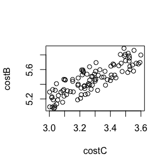

```r
plot(data=costparz,costB ~ costC) #view
```

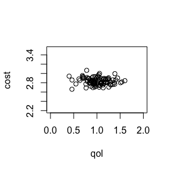

```r
qls <- paste0('qol',LETTERS[1:9]) # QoL variables
for(ql in qls)
  costparz[,ql] <- costparz[,ql] * runif(nrow(costparz)) #perturb
# renew cost data
costparz$cost <- decT$costfun(costparz) # costs
costparz$qol <- decT$qolfun(costparz) # QoL
plot(data=costparz,cost ~ qol,asp=1,xlim=c(0,2)) #view
```

todo:

- simple
- use lhs
- do some plotting (need to write functions)

## Individual-level simulation

todo:

- simple example
- patient-level covariates
- statistical model for probabilities